# hw4.2

## Homework 4.2: Structure preparation and core/boundary/surface patterning (15 pts)

Because different force fields can be used to run sequence design calculations, it is important to ensure that input structures are “prepared” for subsequent design calculations in the context of the force field that will be used. It’s also useful to constrain the amino acids allowed at design positions to a preset polar/nonpolar pattern.

## Part 1

For this problem upload the Protein G structure file, 1pga.pdb, under the Triad “Standardize Structure” application (“Applications/Structure Preparation/Standardize Structure”) to standardize the structure for subsequent calculations using the Rosetta force field. Under “6-Output/Output files” download 1pga_prepared.pdb and rename to 1pga_prepared_rosetta.pdb. Download the log file under “7-Calculation log” and rename it to 1pga_prepared_rosetta_log.txt. Submit both files along with your homework.

## Part 2

Repeat the process for the Phoenix force field. This can be conveniently done by going back to step “2-Basic Settings” and changing the “Score function” to “Phoenix with covalent terms” and submitting a new job (“5-Submit”). Under “6-Output/Output files” download 1pga_prepared.pdb and rename to 1pga_prepared_phoenix.pdb. Download the log file under “7-Calculation log” and rename it to 1pga_prepared_phoenix_log.txt. Submit both files along with your homework.

## Part 3

Use the “Design Builder” application (“Applications/Analysis/Design Builder”) on the 1pga_prepared_phoenix.pdb file to determine the binary pattern constraint for later sequence designs. After uploading the file in “2-Basic Settings” designate the “Sites” be analyzed as “A/1-56”. This indicates that residue positions 1 through 56 on chain A of the structure will be analyzed (i.e., the full structure). Do not change “Restypes” since only an analysis is needed here. All other settings can be ignored and the job can be submitted under “5-Submit”. Under “6-Output”, “Export” the results table after taking note of the “Class” assigned to each of the 56 positions. In subsequent calculations, “core” will be restricted to nonpolar amino acids, “surf” (i.e., surface) to polar amino acids, and “bndry” (i.e., boundary) will be unrestricted. Rename the exported file to "1pga_binary_pattern." Download the log file under “7-Calculation log” and rename it to 1pga_binary_pattern_log.txt. Submit both files along with your homework. The residue classifications will be used for both the Phoenix and Rosetta calculations in a subsequent problem.

## Part 4

Load 1pga.pdb into PyMOL and create a visualization showing the protein backbone as a “cartoon” in one color and the groups of core, boundary and surface residues as “sticks” in three different colors. Make a figure of the visualization and insert it into your notebook. Show the core residues as “spheres” with the remaining residues remaining as “sticks” to get a sense of the packing density in the core of the protein and how the boundary residues and protein backbone shield the core from solvent exposure. Make a figure of the visualization and insert it into your notebook. Ensure the figure files are submitted with your homework.

```python
# code to get list of residues for each class
import pandas as pd
df = pd.read_csv("1pga_binary_pattern.csv")
boundary = df[df.Class == 'surf'].PID.to_list()
# boundary = '+'.join([b[2:] for b in boundary])
boundary = [int(b[2:]) for b in boundary]
boundary[7:]
```

```
[13,
 14,
 15,
 17,
 19,
 21,
 22,
 23,
 24,
 27,
 28,
 31,
 32,
 35,
 36,
 37,
 38,
 40,
 41,
 42,
 43,
 44,
 46,
 47,
 48,
 49,
 51,
 53,
 55]
```

Gray = backbone, Blue = Core, Pink = Surface, Green = Boundary

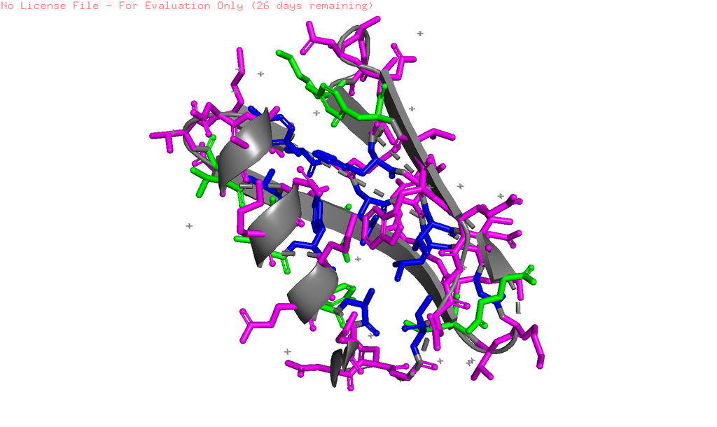

Gray = backbone, Blue = Core, Pink = Surface, Green = Boundary

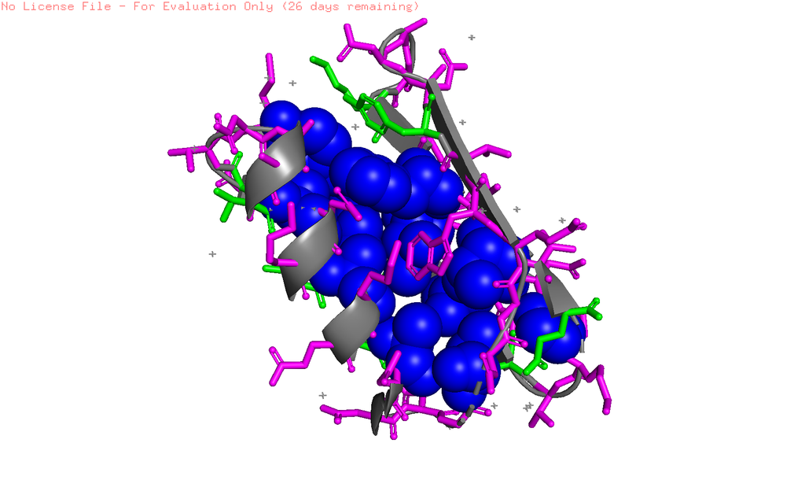